# Project: Investigate a Dataset - [FBI Gun Data]

### Research Question 3(Which state had the highest growth of gun registrations)

To find which state had the highest growth of gun registration, I subtracted the most dated year from the most recent. I used the years 2016 and 2002 because the years 1998-2001 lacked data on some states such as the virgin islands and 2017 was incomplete

```python
ttl2016=df_gun.query('year=="2016"').groupby('state').totals.sum()
```

```python
ttl2002=df_gun.query('year=="2002"').groupby('state').totals.sum()
```

```python
height=ttl2016-ttl2002
```

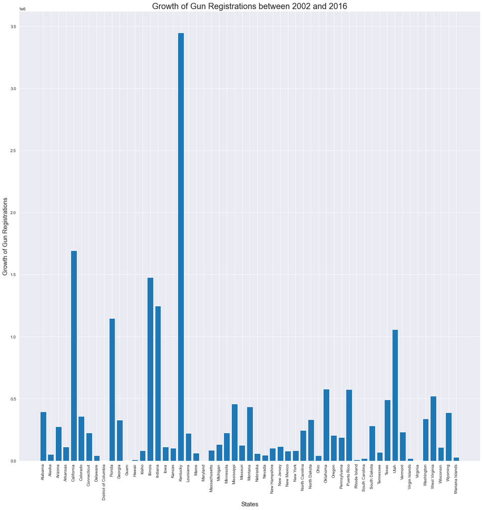

```python
plt.subplots(figsize=(20,20))
plt.bar(labels, height)
plt.xticks(rotation='vertical')
plt.ylabel('Growth of Gun Registrations', fontdict={'fontsize': 15})
plt.xlabel('States', fontdict={'fontsize': 15})
plt.title('Growth of Gun Registrations between 2002 and 2016', fontdict={'fontsize':20});
```

From the above chart, we can see that kentucky had the highest growth of gun registrations from 2002 to 2016

The virgin islands have one of the lowest growth gun registrations despite having nearly no gun registrations in 2002

### Research Question 4 (Which census data is most associated with a high gun per capita)

```python
def plotscatter(df,a,b):
    for i in b:
        df.plot.scatter(x=a,y=i)
        plt.title(i.capitalize().replace('_',' '), fontdict={'fontsize': 15})
```

```python
total_guns =df_gun.groupby('state').estimated_total_sale.sum()
population_estimate = df_census['Population estimates, July 1, 2016,  (V2016)']
gun_per_capita=pd.DataFrame(total_guns/population_estimate)
gun_per_capita.columns = ['totals']
```

```python
censusmerge = df_census.merge(gun_per_capita, how='outer', left_index=True, right_index=True)
```

```python
censusmerge.rename(columns = lambda x:x.strip().lower().replace(" ","_"), inplace = True)
```

```python
d=censusmerge.corr()
```

```python
d['totals'].sort_values().iloc[:10]
```

```
median_gross_rent,_2011-2015                                                             -0.574897
median_selected_monthly_owner_costs_-with_a_mortgage,_2011-2015                          -0.572849
population_per_square_mile,_2010                                                         -0.562706
mean_travel_time_to_work_(minutes),_workers_age_16_years+,_2011-2015                     -0.559025
foreign_born_persons,_percent,_2011-2015                                                 -0.532549
median_selected_monthly_owner_costs_-without_a_mortgage,_2011-2015                       -0.503722
median_value_of_owner-occupied_housing_units,_2011-2015                                  -0.480563
language_other_than_english_spoken_at_home,_percent_of_persons_age_5_years+,_2011-2015   -0.472539
asian_alone,_percent,_july_1,_2016,__(v2016)                                             -0.445086
median_household_income_(in_2015_dollars),_2011-2015                                     -0.443128
Name: totals, dtype: float64
```

```python
d['totals'].sort_values().iloc[-10:]
```

```
owner-occupied_housing_unit_rate,_2011-2015                                -0.015546
white_alone,_percent,_july_1,_2016,__(v2016)                                0.042009
persons_in_poverty,_percent                                                 0.093419
persons__without_health_insurance,_under_age_65_years,_percent              0.121804
white_alone,_not_hispanic_or_latino,_percent,_july_1,_2016,__(v2016)        0.133514
total_retail_sales_per_capita,_2012                                         0.158681
with_a_disability,_under_age_65_years,_percent,_2011-2015                   0.178161
land_area_in_square_miles,_2010                                             0.338603
american_indian_and_alaska_native_alone,_percent,_july_1,_2016,__(v2016)    0.340047
totals                                                                      1.000000
Name: totals, dtype: float64
```

From the above, the census data with the strongest correlations are those related to communities.

`Median gross rent, 2011-2015`, `Median selected monthly owner costs -with a mortgage, 2011-2015`,v`Median selected monthly owner costs -without a mortgage, 2011-2015`, `Median value of owner-occupied housing units, 2011-2015`, `Median household income (in 2015 dollars), 2011-2015`, `Median value of owner-occupied housing units, 2011-2015` are all related to the populations income and neighbourhood

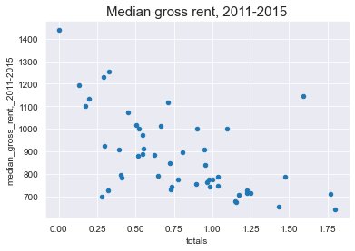

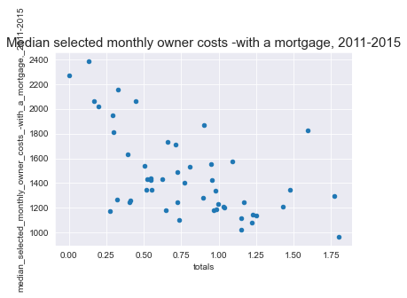

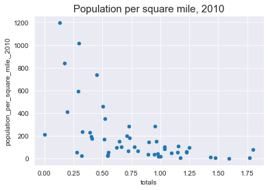

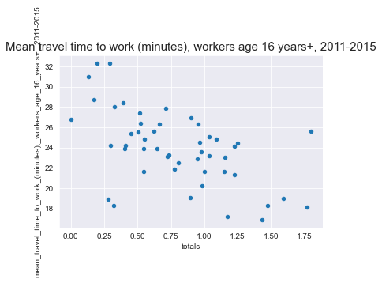

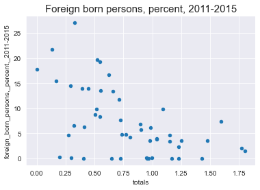

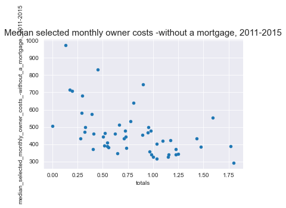

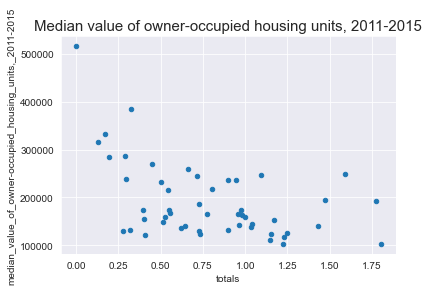

```python
plotscatter(censusmerge, 'totals', ['median_gross_rent,_2011-2015','median_selected_monthly_owner_costs_-with_a_mortgage,_2011-2015','population_per_square_mile,_2010','mean_travel_time_to_work_(minutes),_workers_age_16_years+,_2011-2015','foreign_born_persons,_percent,_2011-2015', 'median_selected_monthly_owner_costs_-without_a_mortgage,_2011-2015', 'median_value_of_owner-occupied_housing_units,_2011-2015'])
```

## Conclusions

> Q2 - The state with the most background checks was kentucky; followed by Utah and California. The state with the most sales is Utah; followed by California and Puerto Rico. The common trend is for the background checks to be greater than gun sales although there are exceptions to this. Further research is advised into te cause fpr this

> Q3 - Kentucky had the highest gun growth; followed by California and Illinois

> Q4 - From the results, the census data most closely related to gun per capita is the median gross rent. It has a negative correlation with it and as such, the lower the rent, the more people in the community own guns. Other factors that influence gun ownership include race,population and curiously, travel time to work. Further researc is required.

## Limitations

> The biggest limitation is the lack of accurate sales data. Conclusions made from analysing the sales data are thus not completely accurate,

```python
from subprocess import call
call(['python', '-m', 'nbconvert', 'Investigate_a_Dataset.ipynb'])
```

```
4294967295
```